# Energy Forecasting

Sameer Lalit Lipsa

October 27, 2016

## 1 Multiple-Linear Regression

Multiple linear regression is the most common form of linear regression analysis. As a predictive analysis, the multiple linear regression is used to explain the relationship between one continuous dependent variable from two or more independent variables. The independent variables can be continuous or categorical (dummy coded as appropriate).

### 1.1 Applying Multiple-Linear Regression to our dataset

#### 1.1.1 Dataset import and structure reset

We will import and check the structure of our cleansed dataset to be used to build our model

```r
setwd("C:/Users/Samy/Dropbox/ADS/Assignment2")
mergeData <-  read.csv("MergedData.csv",header = TRUE)
str(mergeData)
```

```
## 'data.frame':    8687 obs. of  22 variables:
##  $ X                   : int  1 2 3 4 5 6 7 8 9 10 ...
##  $ Date                : Factor w/ 365 levels "2014-01-01","2014-01-02",..: 1 1 1 1 1 1 1 1 1 1 ...
##  $ hour                : int  0 1 2 3 4 5 6 7 8 9 ...
##  $ Account             : num  2.69e+10 2.69e+10 2.69e+10 2.69e+10 2.69e+10 ...
##  $ Channel             : Factor w/ 1 level "MILDRED SCHOOL 1": 1 1 1 1 1 1 1 1 1 1 ...
##  $ Units               : Factor w/ 1 level "kWh": 1 1 1 1 1 1 1 1 1 1 ...
##  $ month               : int  1 1 1 1 1 1 1 1 1 1 ...
##  $ day                 : int  1 1 1 1 1 1 1 1 1 1 ...
##  $ year                : int  2014 2014 2014 2014 2014 2014 2014 2014 2014 2014 ...
##  $ Day.of.Week         : int  4 4 4 4 4 4 4 4 4 4 ...
##  $ weekday             : int  1 1 1 1 1 1 1 1 1 1 ...
##  $ Kwh                 : num  132 133 129 126 129 ...
##  $ PeakHour            : int  0 0 0 0 0 0 0 1 1 1 ...
##  $ TemperatureF        : num  23 21.9 21.9 21.9 21 21 21 19.9 23 24.1 ...
##  $ Dew_PointF          : num  5 3.9 3.9 3 3 3 3.9 5 6.1 5 ...
##  $ Humidity            : num  46 46 46 44 46 46 48 52 48 44 ...
##  $ Sea_Level_PressureIn: num  30.2 30.2 30.2 30.3 30.3 ...
##  $ VisibilityMPH       : num  10 10 10 10 10 10 10 10 10 10 ...
##  $ Wind_SpeedMPH       : num  8.1 11.5 12.7 11.5 9.2 11.5 10.4 10.4 10.4 16.1 ...
##  $ WindDirDegrees      : num  290 290 240 250 260 270 250 230 260 300 ...
##  $ Conditions          : Factor w/ 25 levels "Blowing Snow",..: 2 19 2 2 2 2 22 22 22 22 ...
##  $ Wind_Direction      : Factor w/ 18 levels "Calm","East",..: 17 17 18 18 16 16 18 14 16 17 ...
```

We would like to restructure some of the columns of the dataset and remove the unwanted columns, the datatypes of columns is understood intuitively by r, so we have to make sure the correct structure before proceeding for computation.

```r
require(dplyr)
mergeData <- mergeData %>% select(-c(X,Date,Account,Channel,Units,year))

mergeData$hour <- as.numeric(mergeData$hour)
mergeData$month <- as.numeric(mergeData$month)
mergeData$Day.of.Week <-  as.numeric(mergeData$Day.of.Week)
mergeData$weekday <-  as.numeric(mergeData$weekday)
mergeData$PeakHour <- as.numeric(mergeData$PeakHour)
mergeData$day <- as.numeric(mergeData$day)
```

We remove the categorical columns because it will not be useful in regression model and keeping subset of the data frame which only contains numeric features.

```r
merge.sel <- subset(mergeData,select = -c(Conditions,Wind_Direction))
# Re-Check the structure
str(mergeData)
```

```
## 'data.frame':    8687 obs. of  16 variables:
##  $ hour                : num  0 1 2 3 4 5 6 7 8 9 ...
##  $ month               : num  1 1 1 1 1 1 1 1 1 1 ...
##  $ day                 : num  1 1 1 1 1 1 1 1 1 1 ...
##  $ Day.of.Week         : num  4 4 4 4 4 4 4 4 4 4 ...
##  $ weekday             : num  1 1 1 1 1 1 1 1 1 1 ...
##  $ Kwh                 : num  132 133 129 126 129 ...
##  $ PeakHour            : num  0 0 0 0 0 0 0 1 1 1 ...
##  $ TemperatureF        : num  23 21.9 21.9 21.9 21 21 21 19.9 23 24.1 ...
##  $ Dew_PointF          : num  5 3.9 3.9 3 3 3 3.9 5 6.1 5 ...
##  $ Humidity            : num  46 46 46 44 46 46 48 52 48 44 ...
##  $ Sea_Level_PressureIn: num  30.2 30.2 30.2 30.3 30.3 ...
##  $ VisibilityMPH       : num  10 10 10 10 10 10 10 10 10 10 ...
##  $ Wind_SpeedMPH       : num  8.1 11.5 12.7 11.5 9.2 11.5 10.4 10.4 10.4 16.1 ...
##  $ WindDirDegrees      : num  290 290 240 250 260 270 250 230 260 300 ...
##  $ Conditions          : Factor w/ 25 levels "Blowing Snow",..: 2 19 2 2 2 2 22 22 22 22 ...
##  $ Wind_Direction      : Factor w/ 18 levels "Calm","East",..: 17 17 18 18 16 16 18 14 16 17 ...
```

The structure of the dataset is now ready for computation.

#### 1.1.2 Feature Transformation

There are multiple methods of feature creation and data transformation. Often, finding the right transformation of your data can reveal relationships that would be difficult see otherwise, and may also make it easier for your model to separate classes. In the simple case of creating linear models for regression, this can take the form of squaring terms, taking their logarithm, or other functional transformations that bring the fundamental problem back into a linear relationship through the transformation.

We will start by checking non linearity in the model. We will use the library psych

- psych: Adapted from the help page for pairs, pairs.panels shows a scatter plot of matrices (SPLOM), with bi variate scatter plots below the diagonal, histograms on the diagonal, and the Pearson correlation above the diagonal.

```r
require(psych)
#pairs.panels(merge.sel,col="red")
```

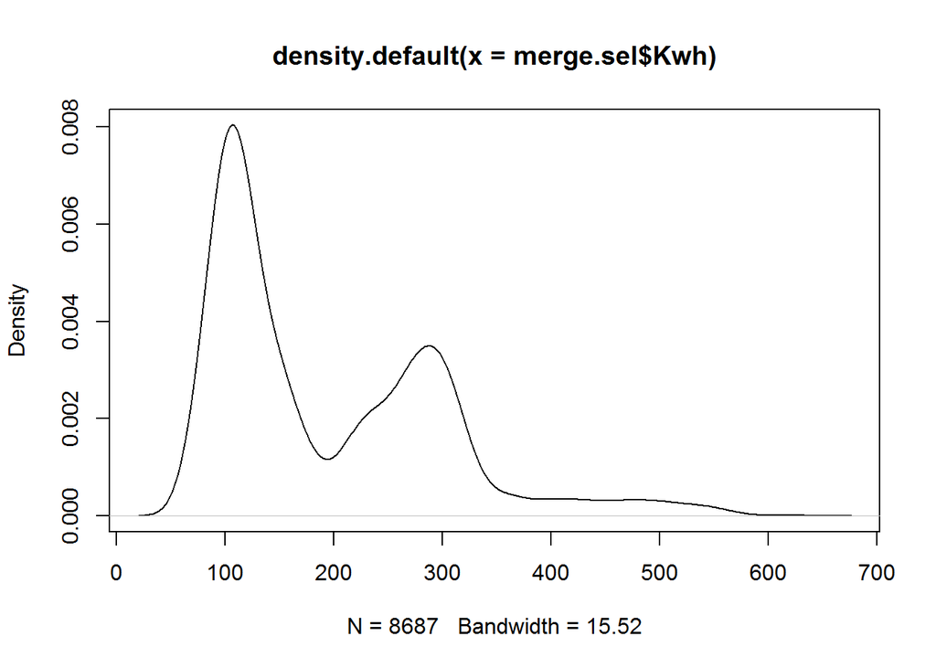

```r
plot(density(merge.sel$Kwh))
```

As seen from the distribution of KwH, we will use a log scale to convert the feature, which is nothing but our dependent variable.

We plot again with transformed predictor i.e. KwH to check if the distribution still looks skewed as in last plot

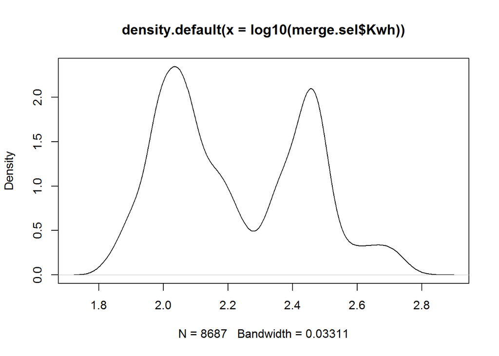

```r
plot(density(log10(merge.sel$Kwh)))
```

The plot looks very much distributed to we will update the transformed predictor value in our dataset as well.

```r
merge.sel$Kwh <- log10(merge.sel$Kwh)
```

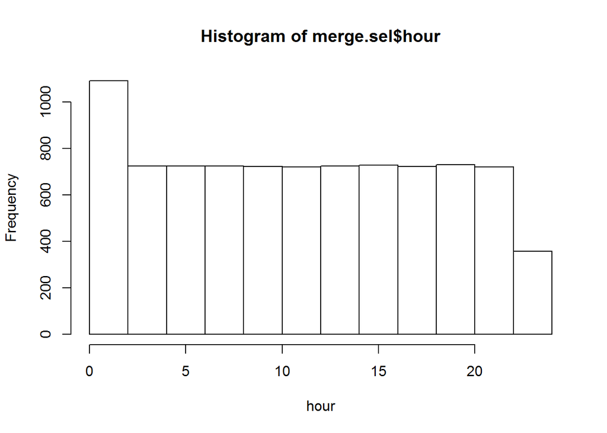

```r
hist(merge.sel$hour, xlab = 'hour')
```

We plot this graph again using scatter.smooth() function. * scatter.smooth():Plot and add a smooth curve computed by loses to a scatter plot.

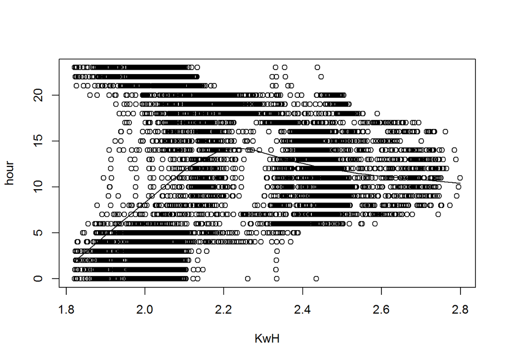

```r
scatter.smooth(x=merge.sel$Kwh,y=merge.sel$hour,xlab = 'KwH', ylab = 'hour')
```

In r we have other methods for feature transformation, we find lambda transformation to be useful to demonstrate with `Day Of Week` parameter.

- forecast library: Methods and tools for displaying and analyzing uni variate time series forecasts including exponential smoothing via state space models and automatic ARIMA modelling.
- BoxCox.lambda(): It is procedure to identify an appropriate exponent (lambda) to transform the data to improve its normality.

We use lambda transformation for `Day Of Week` and update the transformed value to our dataset.

```r
library(forecast)
lambda <- BoxCox.lambda(merge.sel$Day.of.Week)
merge.sel$Day.of.Week <- BoxCox(merge.sel$Day.of.Week,lambda = lambda)
```

#### 1.1.3 Feature Selection

Selecting the right features in your data can mean the difference between mediocre performance with long training times and great performance with short training times, thus we do feature selection.

We will use leaps library for feature selection. leaps() performs an exhaustive search for the best subsets of the variables in x for predicting y in linear regression, using an efficient branch-and-bound algorithm. It is a compatibility wrapper for regsubsets does the same thing better.

```r
library(leaps)
```

#### 1.1.3.1 Feature Selection Exhaustive Search

- regsubsets(): Model selection by exhaustive search, forward or backward stepwise, or sequential replacement

```r
regsubsets.out <- regsubsets(Kwh ~ ., data = merge.sel, nvmax = 14,method = "exhaustive")
res <- summary(regsubsets.out)
```

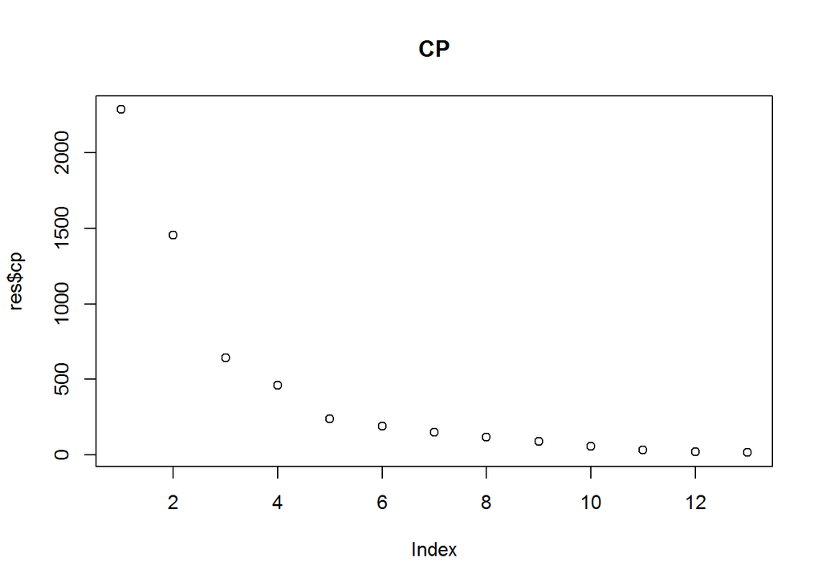

```r
plot(res$cp, main = "CP")
```

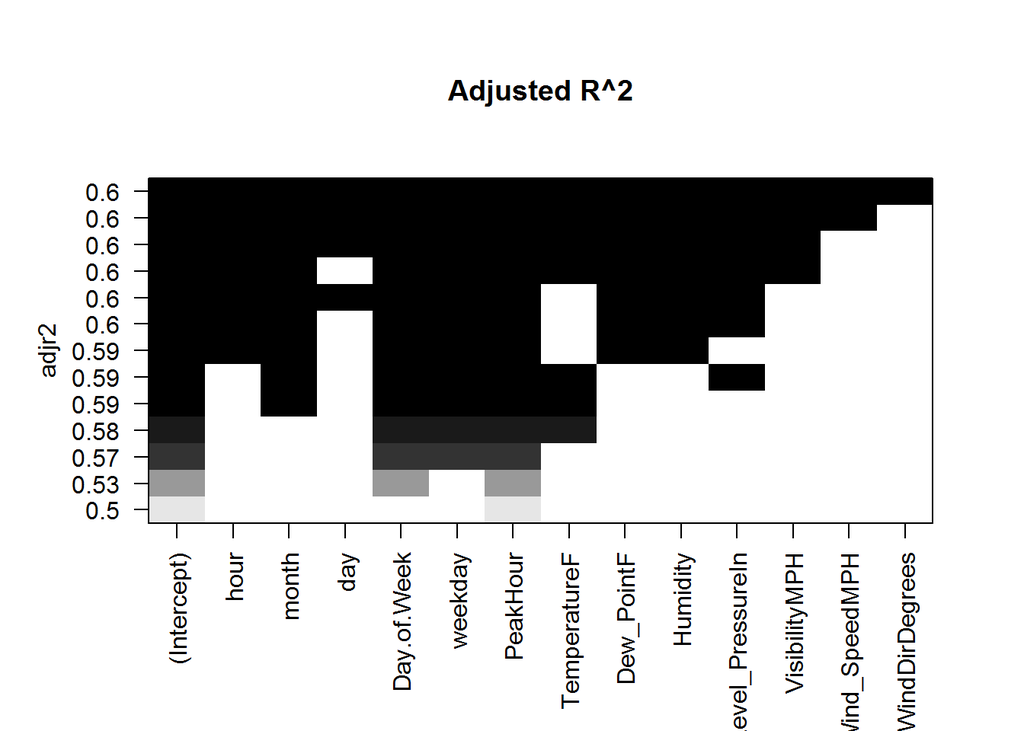

```r
plot(regsubsets.out, scale = "adjr2", main = "Adjusted R^2")
```

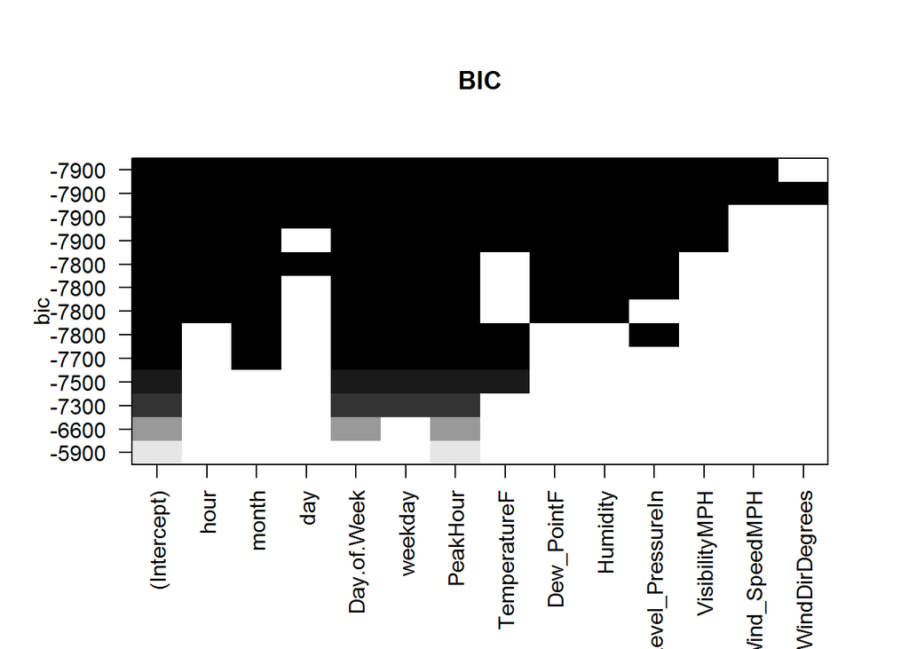

```r
plot(regsubsets.out, scale = "bic", main = "BIC")
```

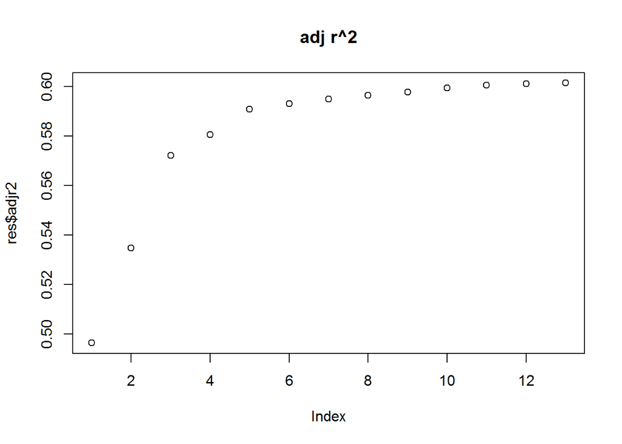

```r
plot(res$adjr2, main = "adj r^2")
```

```r
coef(regsubsets.out,10)
```

```
##          (Intercept)                 hour                month
##          0.986612992         -0.001518070         -0.006809980
##          Day.of.Week              weekday             PeakHour
##          0.175084366          0.120601290          0.308369670
##         TemperatureF           Dew_PointF             Humidity
##         -0.006847200          0.009347132         -0.004853796
## Sea_Level_PressureIn        VisibilityMPH
##          0.041667612         -0.006239505
```

```r
res$adjr2[10]
```

```
## [1] 0.5993363
```

#### 1.1.3.2 Feature Selection Forward Search

```r
regsubsets.out <- regsubsets(Kwh ~ ., data = merge.sel, nvmax = 14,method = "forward")
res <- summary(regsubsets.out)
```

Statistics:

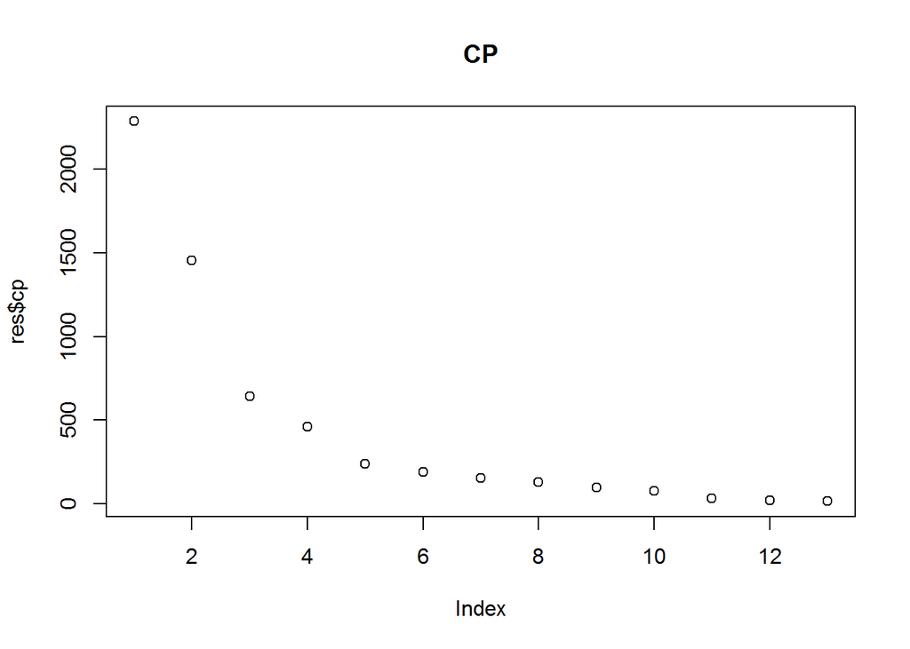

```r
plot(res$cp, main = "CP")
```

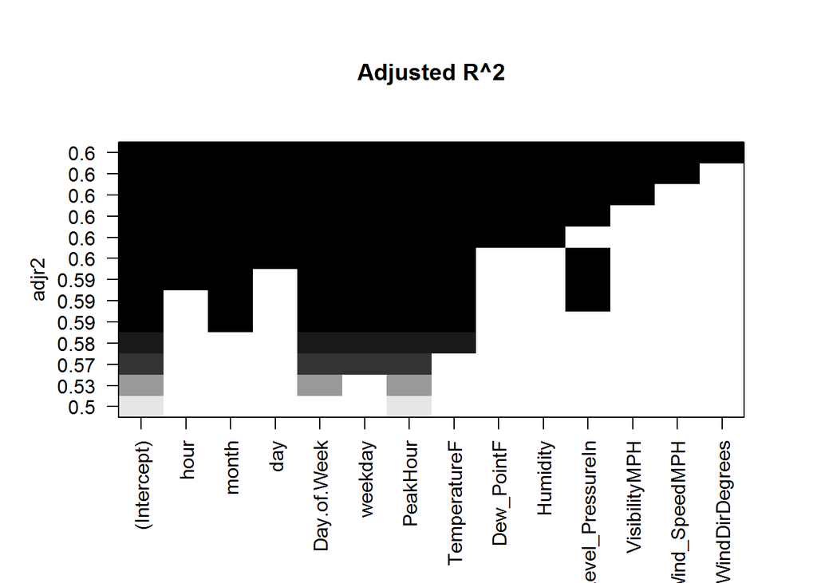

```r
plot(regsubsets.out, scale = "adjr2", main = "Adjusted R^2")
```

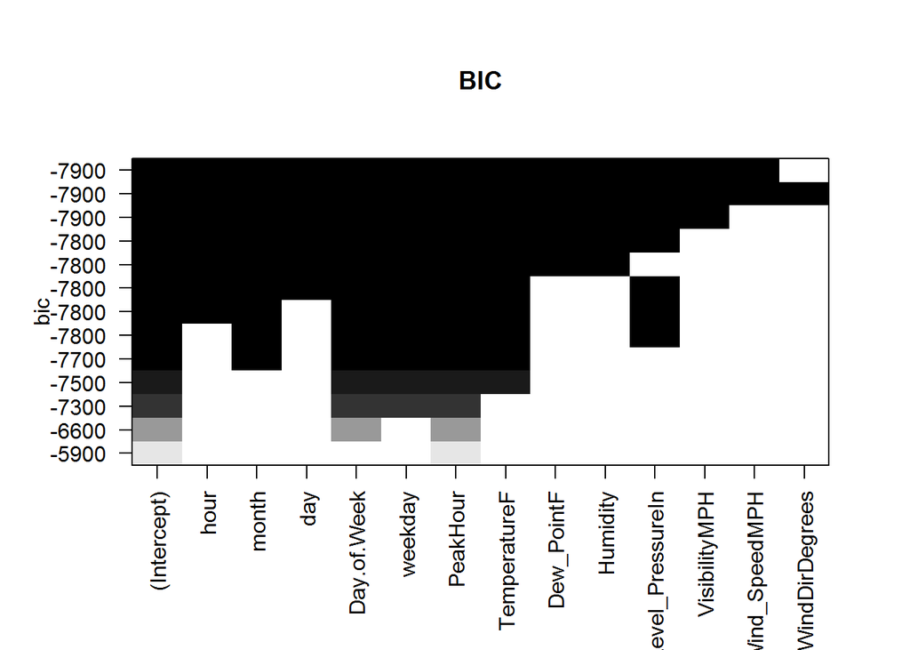

```r
plot(regsubsets.out, scale = "bic", main = "BIC")
```

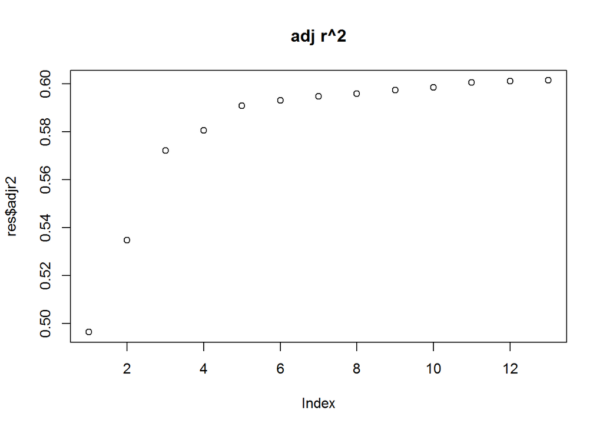

```r
plot(res$adjr2, main = "adj r^2")
```

```r
coef(regsubsets.out,10)
```

```
##          (Intercept)                 hour                month
##         1.0777456959        -0.0014628085        -0.0070198703
##                  day          Day.of.Week              weekday
##        -0.0009535587         0.1773663822         0.1218297525
##             PeakHour         TemperatureF           Dew_PointF
##         0.3124898552        -0.0039129652         0.0060353058
##             Humidity Sea_Level_PressureIn
##        -0.0030071928         0.0323572775
```

```r
res$adjr2[10]
```

```
## [1] 0.5984361
```

#### 1.1.3.3 Feature Selection Backward Search

```r
regsubsets.out <- regsubsets(Kwh ~ ., data = merge.sel, nvmax = 14,method = "backward")
res <- summary(regsubsets.out)
```

Statistics:

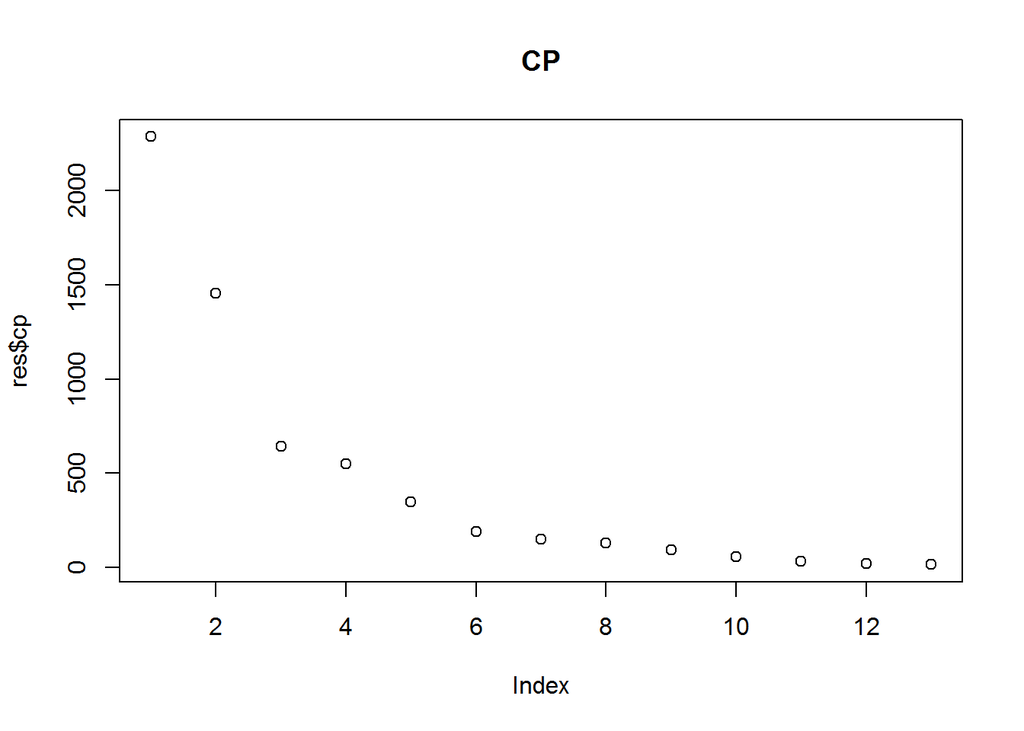

```r
plot(res$cp, main = "CP")
```

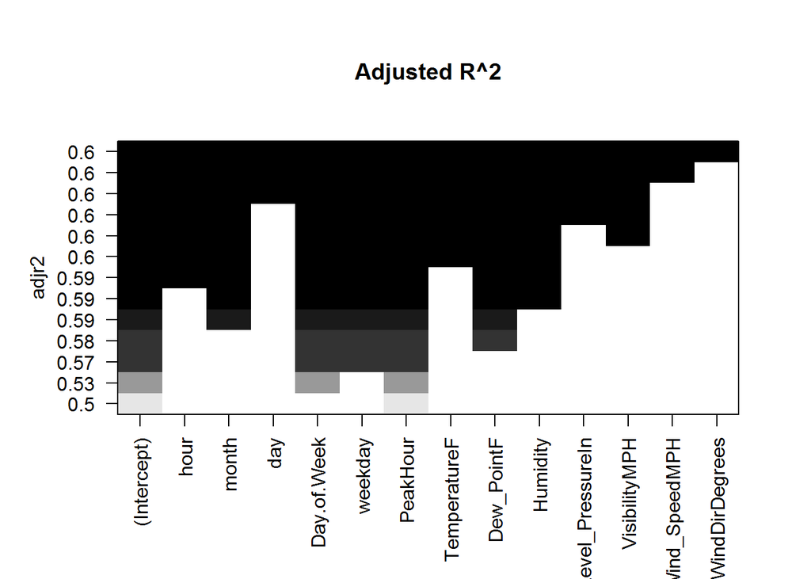

```r
plot(regsubsets.out, scale = "adjr2", main = "Adjusted R^2")
```

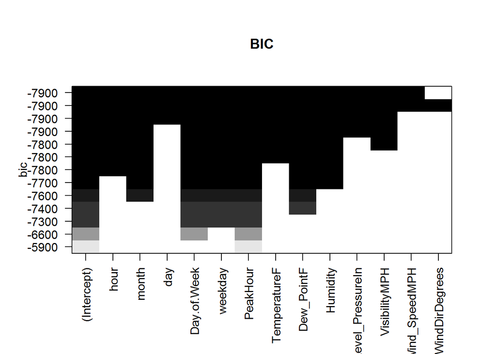

```r
plot(regsubsets.out, scale = "bic", main = "BIC")
```

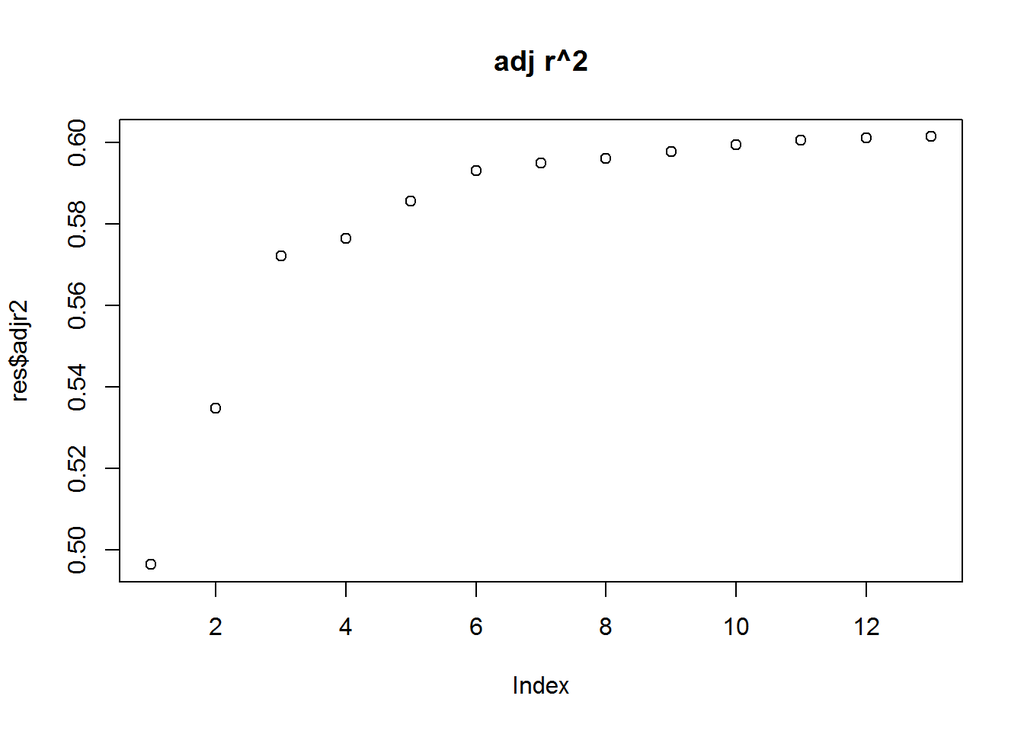

```r
plot(res$adjr2, main = "adj r^2")
```

```r
coef(regsubsets.out,10)
```

```
##          (Intercept)                 hour                month
##          0.986612992         -0.001518070         -0.006809980
##          Day.of.Week              weekday             PeakHour
##          0.175084366          0.120601290          0.308369670
##         TemperatureF           Dew_PointF             Humidity
##         -0.006847200          0.009347132         -0.004853796
## Sea_Level_PressureIn        VisibilityMPH
##          0.041667612         -0.006239505
```

```r
res$adjr2[10]
```

```
## [1] 0.5993363
```

#### 1.1.3.4 Feature Selection Manually selecting features

```r
regsubsets.step <- regsubsets(Kwh~hour + month + day + Day.of.Week + weekday + PeakHour +
                                TemperatureF + Dew_PointF + Humidity +
                                VisibilityMPH, data = merge.sel, nvmax =14 )
summary(regsubsets.step)
```

```
## Subset selection object
## Call: regsubsets.formula(Kwh ~ hour + month + day + Day.of.Week + weekday +
##     PeakHour + TemperatureF + Dew_PointF + Humidity + VisibilityMPH,
##     data = merge.sel, nvmax = 14)
## 10 Variables  (and intercept)
##               Forced in Forced out
## hour              FALSE      FALSE
## month             FALSE      FALSE
## day               FALSE      FALSE
## Day.of.Week       FALSE      FALSE
## weekday           FALSE      FALSE
## PeakHour          FALSE      FALSE
## TemperatureF      FALSE      FALSE
## Dew_PointF        FALSE      FALSE
## Humidity          FALSE      FALSE
## VisibilityMPH     FALSE      FALSE
## 1 subsets of each size up to 10
## Selection Algorithm: exhaustive
##           hour month day Day.of.Week weekday PeakHour TemperatureF
## 1  ( 1 )  " "  " "   " " " "         " "     "*"      " "
## 2  ( 1 )  " "  " "   " " "*"         " "     "*"      " "
## 3  ( 1 )  " "  " "   " " "*"         "*"     "*"      " "
## 4  ( 1 )  " "  " "   " " "*"         "*"     "*"      "*"
## 5  ( 1 )  " "  "*"   " " "*"         "*"     "*"      "*"
## 6  ( 1 )  " "  "*"   " " "*"         "*"     "*"      " "
## 7  ( 1 )  "*"  "*"   " " "*"         "*"     "*"      " "
## 8  ( 1 )  "*"  "*"   "*" "*"         "*"     "*"      " "
## 9  ( 1 )  "*"  "*"   " " "*"         "*"     "*"      "*"
## 10  ( 1 ) "*"  "*"   "*" "*"         "*"     "*"      "*"
##           Dew_PointF Humidity VisibilityMPH
## 1  ( 1 )  " "        " "      " "
## 2  ( 1 )  " "        " "      " "
## 3  ( 1 )  " "        " "      " "
## 4  ( 1 )  " "        " "      " "
## 5  ( 1 )  " "        " "      " "
## 6  ( 1 )  "*"        "*"      " "
## 7  ( 1 )  "*"        "*"      " "
## 8  ( 1 )  "*"        "*"      " "
## 9  ( 1 )  "*"        "*"      "*"
## 10  ( 1 ) "*"        "*"      "*"
```

```r
resstep <- summary(regsubsets.step)
```

Statistics:

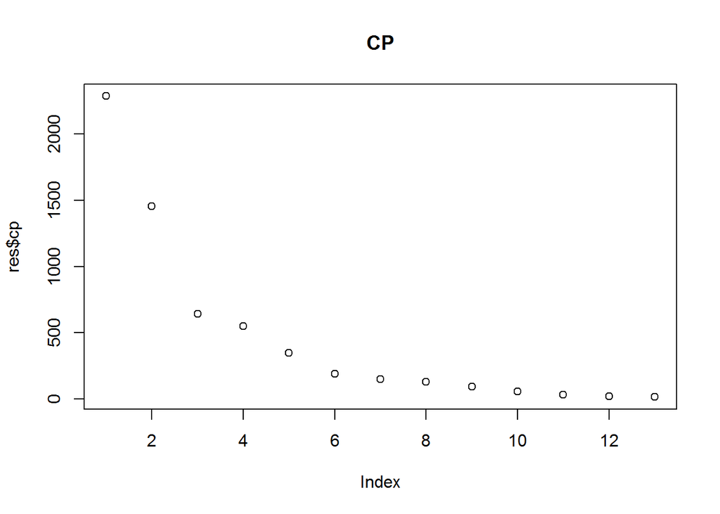

```r
plot(res$cp, main = "CP")
```

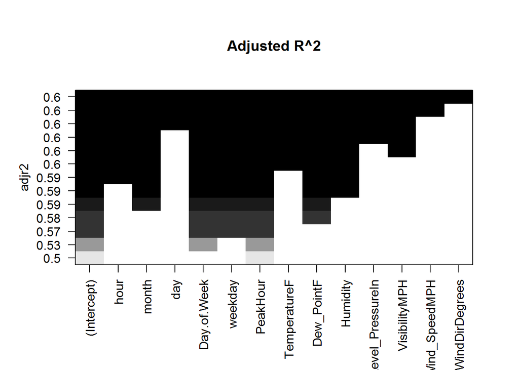

```r
plot(regsubsets.out, scale = "adjr2", main = "Adjusted R^2")
```

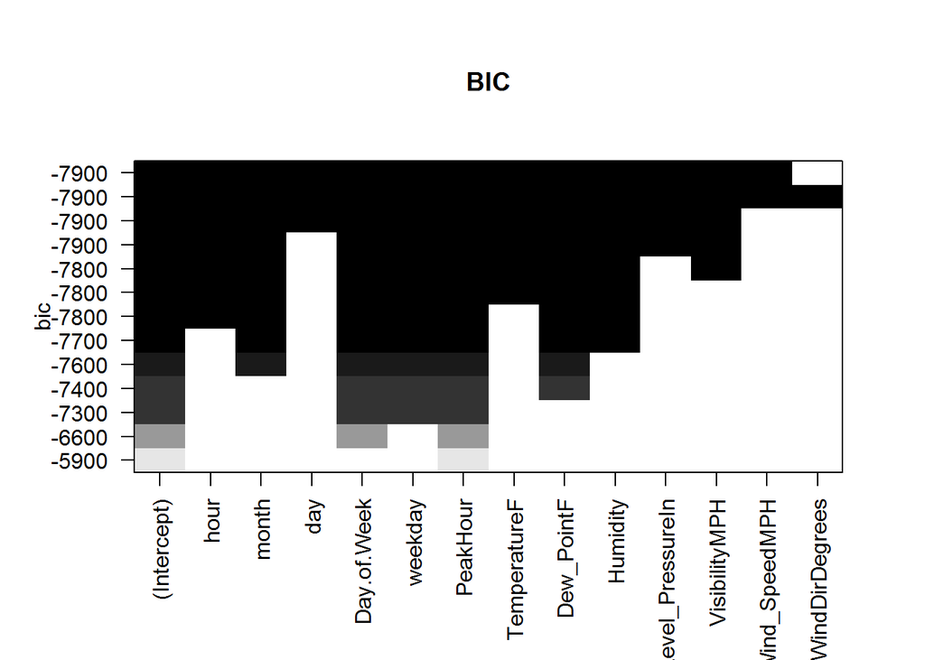

```r
plot(regsubsets.out, scale = "bic", main = "BIC")
```

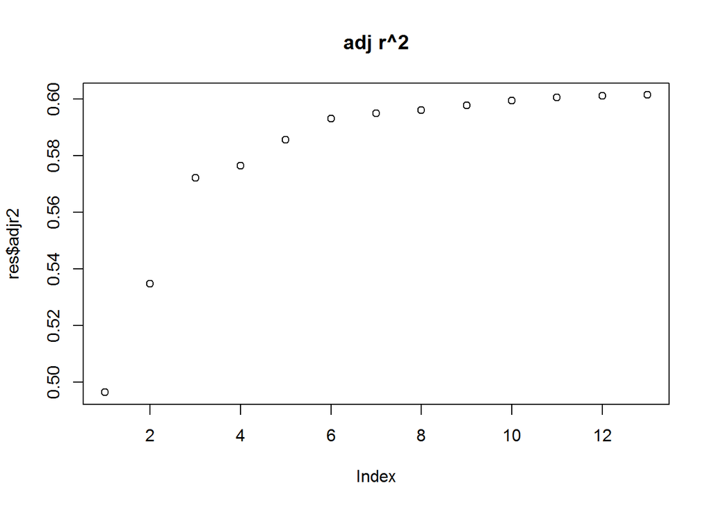

```r
plot(res$adjr2, main = "adj r^2")
```

```r
coef(regsubsets.out,10)
```

```
##          (Intercept)                 hour                month
##          0.986612992         -0.001518070         -0.006809980
##          Day.of.Week              weekday             PeakHour
##          0.175084366          0.120601290          0.308369670
##         TemperatureF           Dew_PointF             Humidity
##         -0.006847200          0.009347132         -0.004853796
## Sea_Level_PressureIn        VisibilityMPH
##          0.041667612         -0.006239505
```

```r
res$adjr2[10]
```

```
## [1] 0.5993363
```

#### 1.1.4 Develop a linear model

Now we Develop a linear model using variables selected from Backward approach. The model will be built using the training sample of the data. The model will be validated using the validation sample of the data.

##### 1.1.4.1 Split Validation

Split the data into training and validation samples. We will use (train.size)% for training and (100-train.size)% for validation

- set.seed(): Set the seed of R’s random number generator, which is useful for creating simulations or random objects that can be reproduced.

We select 80% data for training and rest 20% for the testing and validation.

```r
set.seed(2017)
train.size <- 0.8
train.index <- sample.int(length(merge.sel$Kwh),round(length(merge.sel$Kwh)*train.size))
train.sample <- merge.sel[train.index,]
train.val <- merge.sel[-train.index,]
```

`train.sample` contains our training data and `train.val` contains our remaining validation data.

We will perform additional tests on training data. We will use a stepwise selection of variables by backward elimination. We will consider all possible candidate variables and eliminate one at a time.

- lm():lm is used to fit linear models. It can be used to carry out regression, single stratum analysis of variance and analysis of co-variance.

```r
fit <- lm(Kwh ~ hour + month + Day.of.Week + weekday + PeakHour + TemperatureF + Dew_PointF +
                Humidity + Sea_Level_PressureIn + VisibilityMPH , data = train.sample)
```

By cheeking the summary of `fit` we would get to know the fit of our linear model.

```r
summary(fit)
```

```
##
## Call:
## lm(formula = Kwh ~ hour + month + Day.of.Week + weekday + PeakHour +
##     TemperatureF + Dew_PointF + Humidity + Sea_Level_PressureIn +
##     VisibilityMPH, data = train.sample)
##
## Residuals:
##      Min       1Q   Median       3Q      Max
## -0.50077 -0.10272  0.00021  0.08930  0.49639
##
## Coefficients:
##                        Estimate Std. Error t value Pr(>|t|)
## (Intercept)           1.0740476  0.2314694   4.640 3.55e-06 ***
## hour                 -0.0014895  0.0002559  -5.820 6.16e-09 ***
## month                -0.0067638  0.0005458 -12.392  < 2e-16 ***
## Day.of.Week           0.1760833  0.0048277  36.473  < 2e-16 ***
## weekday               0.1216719  0.0046563  26.130  < 2e-16 ***
## PeakHour              0.3080442  0.0037442  82.272  < 2e-16 ***
## TemperatureF         -0.0064596  0.0012238  -5.278 1.34e-07 ***
## Dew_PointF            0.0089394  0.0012977   6.889 6.12e-12 ***
## Humidity             -0.0046908  0.0005996  -7.823 5.93e-15 ***
## Sea_Level_PressureIn  0.0381529  0.0074093   5.149 2.69e-07 ***
## VisibilityMPH        -0.0060852  0.0009974  -6.101 1.11e-09 ***
## ---
## Signif. codes:  0 '***' 0.001 '**' 0.01 '*' 0.05 '.' 0.1 ' ' 1
##
## Residual standard error: 0.1422 on 6939 degrees of freedom
## Multiple R-squared:  0.6011, Adjusted R-squared:  0.6006
## F-statistic:  1046 on 10 and 6939 DF,  p-value: < 2.2e-16
```

By plotting `fit` it provide checks for heteroscedasticity, normality, and influential observations.

Residuals vs Fitted: This plot shows if residuals have non-linear patterns. There could be a non-linear relationship between predictor variables and an outcome variable and the pattern could show up in this plot if the model doesn’t capture the non-linear relationship.

Normal Q-Q: This plot shows if residuals are normally distributed. Do residuals follow a straight line well or do they deviate severely? It’s good if residuals are lined well on the straight dashed line.

Scale-Location: It’s also called Spread-Location plot. This plot shows if residuals are spread equally along the ranges of predictors. This is how you can check the assumption of equal variance (homoscedasticity). It’s good if you see a horizontal line with equally (randomly) spread points.

Residuals vs Leverage: This plot helps us to find influential cases (i.e., subjects) if any. Not all outliers are influential in linear regression analysis (whatever outliers mean).

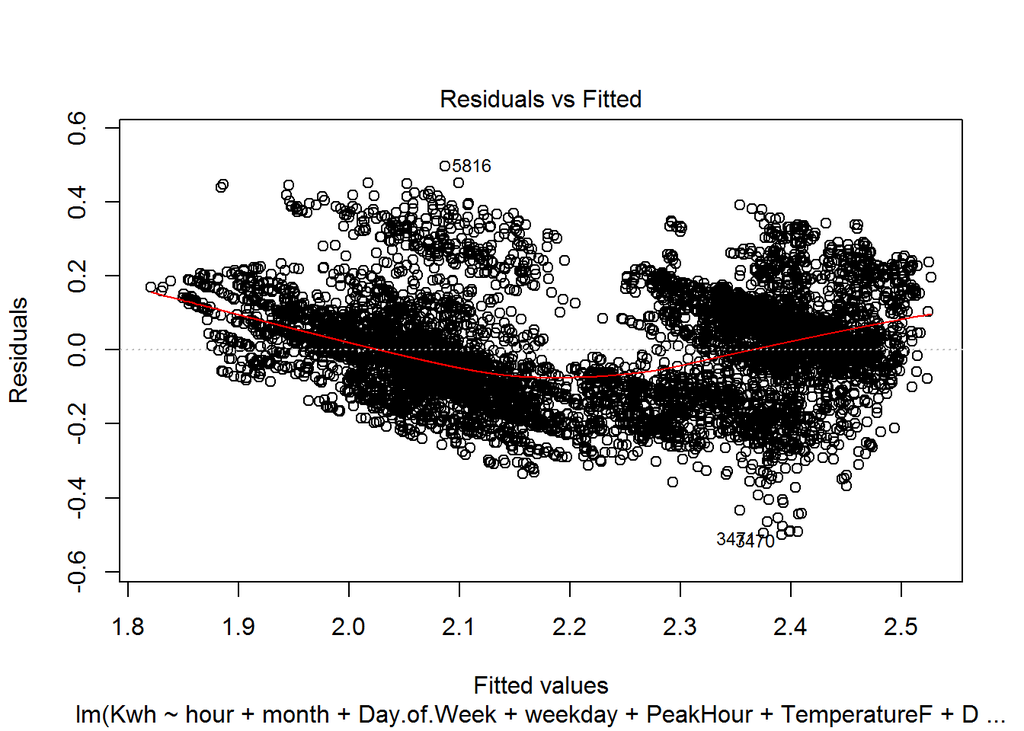

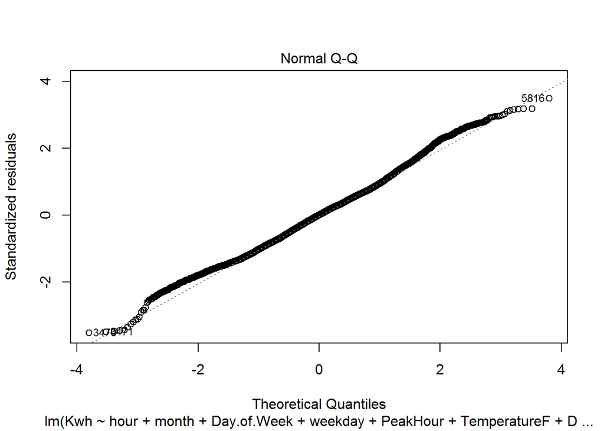

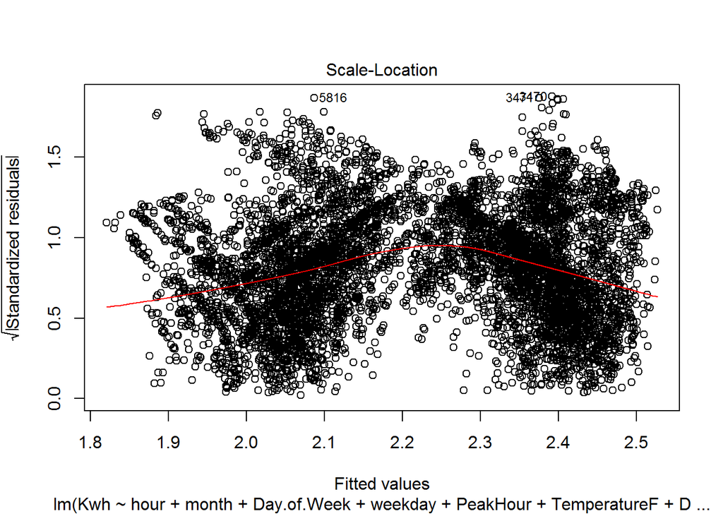

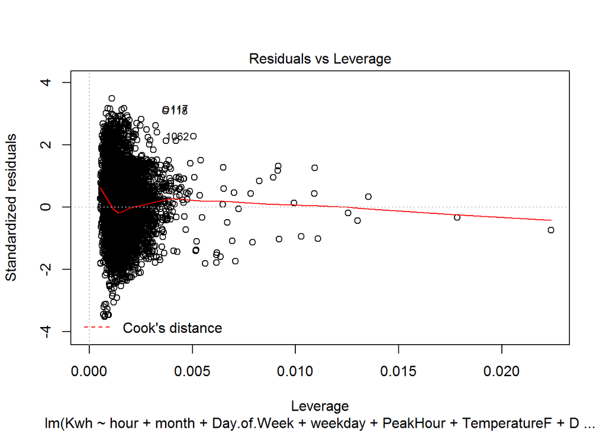

```r
plot(fit)
```

Lets check the distribution of errors around the model using car library. * car library: It is used to compute Correlation and Linear Regression.

```r
library(car)
```

Let us check the correlation and regression for `fit`.

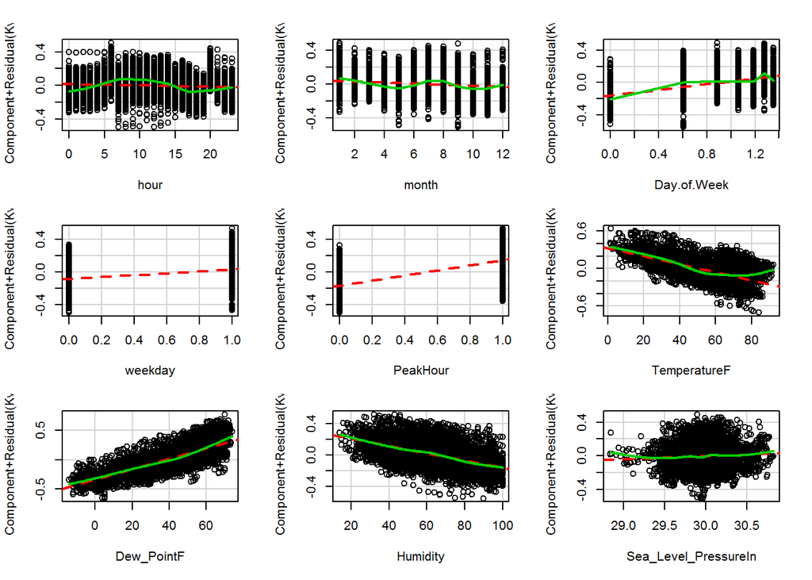

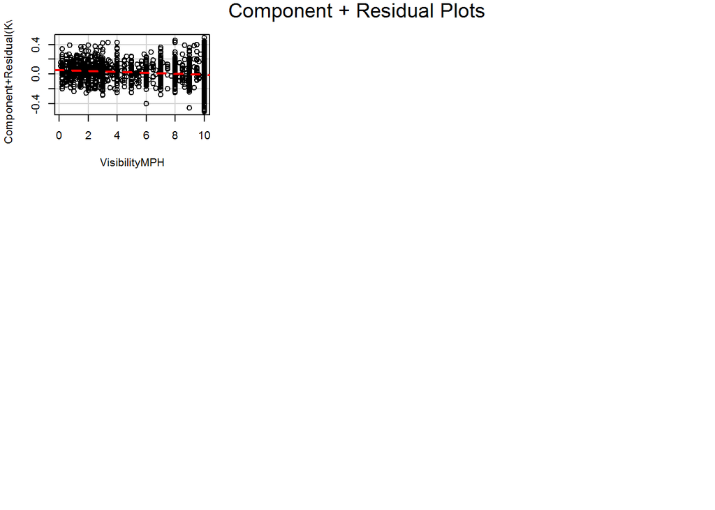

```r
car::crPlots(fit)
```

Red Line is the model and green line shows the fit of the variables.

Cook’s distance is useful for identifying outliers in the X values (observations for predictor variables). It also shows the influence of each observation on the fitted response values. An observation with Cook’s distance larger than three times the mean Cook’s distance might be an outlier.

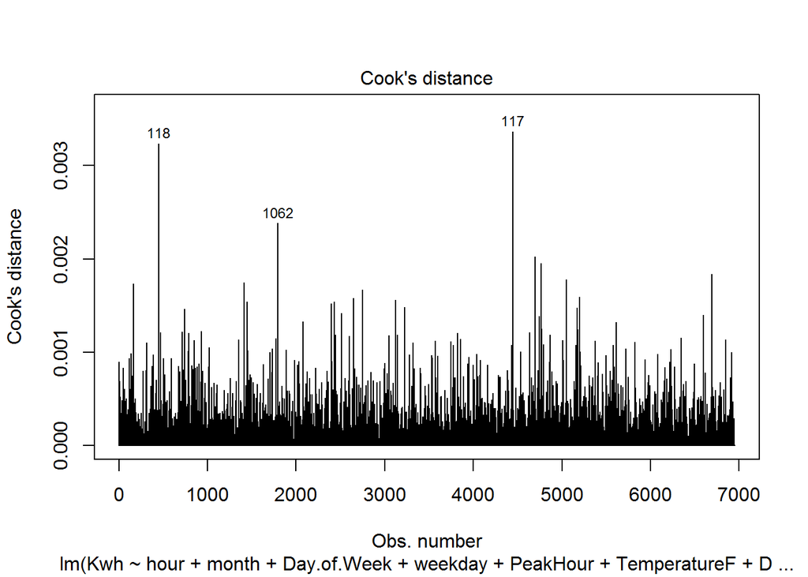

```r
# Cook's D plot, cutoff as 4/(n-k-1)
cutoff <- 4/((nrow(train.sample)-length(fit$coefficients)-2))
# Identify D values > cutoff
plot(fit,which=4, cook.levels = cutoff)
```

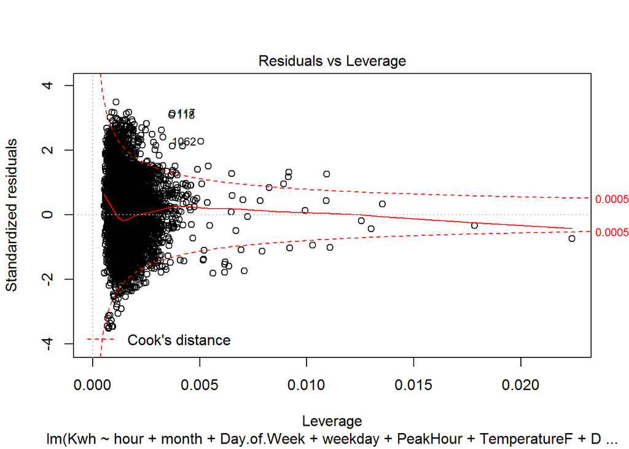

```r
# Check, how important are these observations for the construction of the model
plot(fit,which=5, cook.levels = cutoff)
```

```r
fit <- lm(Kwh ~ hour + month + Day.of.Week + weekday + PeakHour + TemperatureF + Dew_PointF +
                Humidity + Sea_Level_PressureIn + VisibilityMPH , data = train.sample)
```

```r
summary(fit)
```

```
##
## Call:
## lm(formula = Kwh ~ hour + month + Day.of.Week + weekday + PeakHour +
##     TemperatureF + Dew_PointF + Humidity + Sea_Level_PressureIn +
##     VisibilityMPH, data = train.sample)
##
## Residuals:
##      Min       1Q   Median       3Q      Max
## -0.50077 -0.10272  0.00021  0.08930  0.49639
##
## Coefficients:
##                        Estimate Std. Error t value Pr(>|t|)
## (Intercept)           1.0740476  0.2314694   4.640 3.55e-06 ***
## hour                 -0.0014895  0.0002559  -5.820 6.16e-09 ***
## month                -0.0067638  0.0005458 -12.392  < 2e-16 ***
## Day.of.Week           0.1760833  0.0048277  36.473  < 2e-16 ***
## weekday               0.1216719  0.0046563  26.130  < 2e-16 ***
## PeakHour              0.3080442  0.0037442  82.272  < 2e-16 ***
## TemperatureF         -0.0064596  0.0012238  -5.278 1.34e-07 ***
## Dew_PointF            0.0089394  0.0012977   6.889 6.12e-12 ***
## Humidity             -0.0046908  0.0005996  -7.823 5.93e-15 ***
## Sea_Level_PressureIn  0.0381529  0.0074093   5.149 2.69e-07 ***
## VisibilityMPH        -0.0060852  0.0009974  -6.101 1.11e-09 ***
## ---
## Signif. codes:  0 '***' 0.001 '**' 0.01 '*' 0.05 '.' 0.1 ' ' 1
##
## Residual standard error: 0.1422 on 6939 degrees of freedom
## Multiple R-squared:  0.6011, Adjusted R-squared:  0.6006
## F-statistic:  1046 on 10 and 6939 DF,  p-value: < 2.2e-16
```

Also checking the correlation and regression for `fit`.

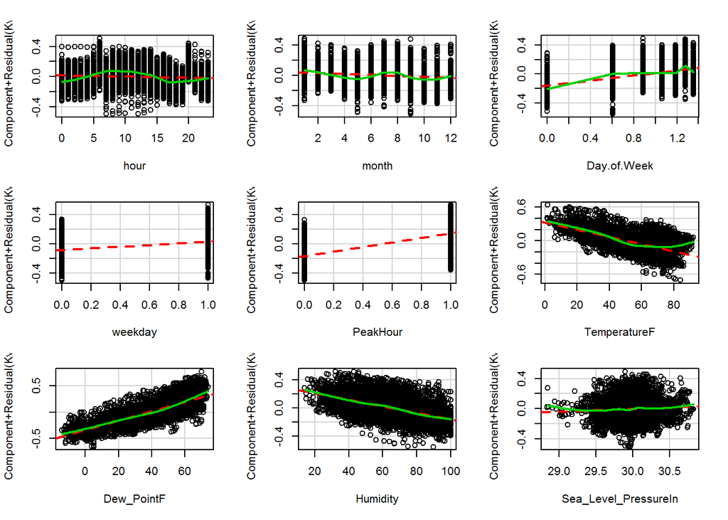

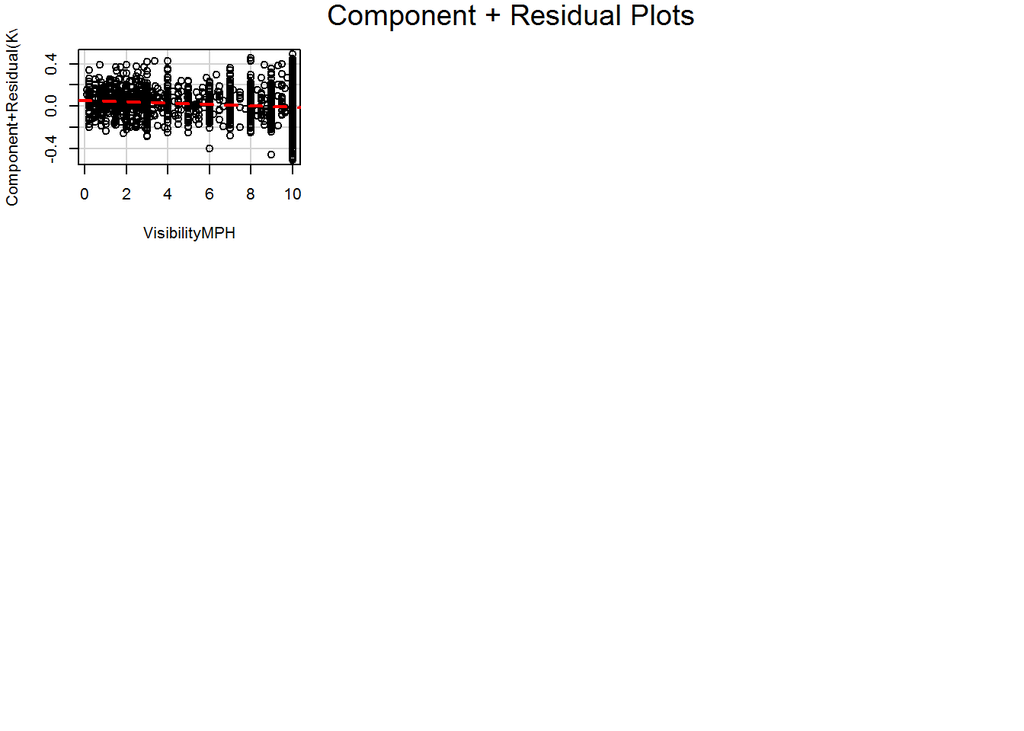

```r
car::crPlots(fit)
```

Plotting Cook’s D plot to recheck the fit.

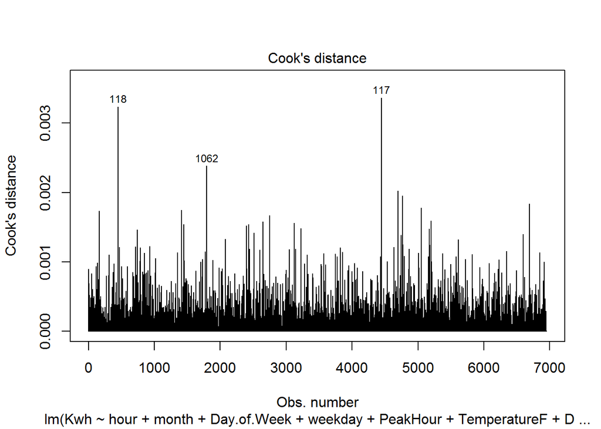

```r
# Cook's D plot, cutoff as 4/(n-k-1)
cutoff <- 4/((nrow(train.sample)-length(fit$coefficients)-2))
# Identify D values > cutoff
plot(fit,which=4, cook.levels = cutoff)
```